# Anális base de datos beauty

Este notebook aplica técnicas de **procesamiento de lenguaje natural (NLP)** para analizar los ingredientes de productos cosméticos a partir del dataset *beauty.parquet* obtenido en:

https://world.openbeautyfacts.org/data

Se cargan y limpian los datos, se implementa un modelo basado en **EntityRuler** de spaCy con patrones construidos a partir de sustancias disruptoras endocrinas y sus alias, y se evalúa su detección en etiquetas de ingredientes.

Posteriormente, se generan **estadísticas descriptivas** (ingredientes con disruptores, número de sustancias detectadas, ratios de detección) y **visualizaciones** que muestran la distribución de disruptores según productos, fuentes regulatorias y anexos cosméticos.

En conjunto, el análisis permite cuantificar la presencia de disruptores en más de **16.000 registros** de los más de 54.000 de la base de datos original y explorar su relación con marcas, productos y estatus regulatorio.

Es un análisis que pone a prueba el modelo de manera masiva.

## 1. Importamos librerias y definimos funciones

### 1.1. Importación librerias

```python
import numpy as np
import json
import spacy
import pandas as pd
from spacy.pipeline import EntityRuler
import re
from plotnine import *
from plotnine.positions import position_stack, position_fill
import sys
from pathlib import Path
```

### 1.2. Importamos Funciones

Para poder importar las funciones tenemos que hacer visible la carpeta de importación porque está en otro nivel

```python
# Hace visible la carpeta 'src' desde cualquier notebook

def add_project_root(marker="src"):
    """Sube directorios desde el cwd hasta encontrar uno que contenga 'src' y lo añade a sys.path."""
    here = Path.cwd()
    for parent in (here, *here.parents):
        if (parent / marker).is_dir():
            p = str(parent)
            if p not in sys.path:
                sys.path.insert(0, p)
            return parent
    raise RuntimeError("No se encontró la raíz del proyecto (carpeta con 'src').")

PROJECT_ROOT = add_project_root()
print("✓ Proyecto:", PROJECT_ROOT)

#  Recarga automáticamente si edito modulos del archivo de funciones
%load_ext autoreload
%autoreload 2
```

```
✓ Proyecto: b:\IMF\TFM\tfm-disruptors
```

```python
def extract_text(x):
    """Extrae el valor asociado a la clave 'text' de un array de diccionarios."""

    # Si es un array de numpy, trátalo como lista
    if isinstance(x, np.ndarray):
        if x.size == 0:
            return np.nan
        for it in x:
            if isinstance(it, dict) and "text" in it:
                return it.get("text") or np.nan
        return np.nan
```

**Funciones de normalización, evaluación de algoritmo y visualización**

```python
from src.nlp.nlp_functions import normalize, normalize_for_pattern, make_ent_id, facet_bar_pct

#normalize depende de: unify_dashes, get_tokens, to_lowercase, no_symbols
```

## 2. Carga y lectura de datos

```python
# Rutas
ruta_patrones = "./entity_ruler_patterns.jsonl"
ruta_parquet       = "../../data/raw/beauty.parquet"
ruta_disruptores = "../../data/processed/notebooks/disruptores_final.parquet"
```

### 2.1 Archivo beauty

De este archivo vamos a obtener el dataframe para realizar el analisis del texto de las etiquetas

```python
df_beauty = pd.read_parquet(ruta_parquet)
df_beauty.info()
```

```
<class 'pandas.core.frame.DataFrame'>
RangeIndex: 54215 entries, 0 to 54214
Data columns (total 90 columns):
 #   Column                                  Non-Null Count  Dtype
---  ------                                  --------------  -----
 0   additives_n                             14347 non-null  float64
 1   additives_tags                          27014 non-null  object
 2   allergens_tags                          43893 non-null  object
 3   brands_tags                             39037 non-null  object
 4   brands                                  39036 non-null  object
 5   categories                              33971 non-null  object
 6   categories_tags                         34010 non-null  object
 7   checkers_tags                           54215 non-null  object
 8   cities_tags                             22610 non-null  object
 9   code                                    54215 non-null  object
```

[output cut: 82 more lines]

```python
# Selección de columnas necesarias
df_text = df_beauty[["ingredients_text", "product_name", "categories"]].copy()
df_text.info()
```

```
<class 'pandas.core.frame.DataFrame'>
RangeIndex: 54215 entries, 0 to 54214
Data columns (total 3 columns):
 #   Column            Non-Null Count  Dtype
---  ------            --------------  -----
 0   ingredients_text  54215 non-null  object
 1   product_name      54215 non-null  object
 2   categories        33971 non-null  object
dtypes: object(3)
memory usage: 1.2+ MB
```

```python
df_text.head(15)
```

|  | ingredients_text | product_name | categories |
| --- | --- | --- | --- |
| 0 | [] | [{'lang': 'main', 'text': 'Kiehls - Cream #gel... |  |
| 1 | [] | [{'lang': 'main', 'text': 'huile de douche Dan... |  |
| 2 | [] | [{'lang': 'main', 'text': 'Rejuvenating Arctic... | None |
| 3 | [] | [{'lang': 'main', 'text': 'Spray'}, {'lang': '... | None |
| 4 | [{'lang': 'main', 'text': 'alcohol denat. (SD ... | [{'lang': 'main', 'text': 'Cèdre eau de toilet... | Parfums, Eaux de toilette |
| 5 | [{'lang': 'main', 'text': 'ethyl & but copolym... | [{'lang': 'main', 'text': 'Sinful colors Gorge... | Maquillage, Maquillage pour les ongles, Vernis... |
| 6 | [] | [{'lang': 'main', 'text': 'Huile de coco - crè... | de:main, en:Crème pour les mains, en:alcoholic... |
| 7 | [{'lang': 'main', 'text': 'Aqua, Sodium C14-16... | [{'lang': 'main', 'text': 'Shampooing soin for... | Cheveux, Shampoings, Shampoings pour cheveux s... |
| 8 | [] | [{'lang': 'main', 'text': 'Après-shampoing hui... |  |
| 9 | [{'lang': 'main', 'text': 'Aqua, Theobroma Cac... | [{'lang': 'main', 'text': 'Lotion de massage A... | Corps, Lotions de massage, Lotions pour le corps |
| 10 | [] | [{'lang': 'main', 'text': 'Men+Care clean comf... | None |
| 11 | [] | [] | None |
| 12 | [] | [] | None |
| 13 | [] | [{'lang': 'main', 'text': 'Kenra volume spray'... | None |
| 14 | [] | [{'lang': 'main', 'text': 'Pure Castile soap t... |  |

Parece que las dos primeras variables están dentro de un diccionario

```python
# Consultamos los tipos reales en la columna
print(df_text["ingredients_text"].map(type).value_counts(),"\n")
print(df_text["product_name"].map(type).value_counts(),"\n")
print(df_text["categories"].map(type).value_counts(),"\n")
```

```
ingredients_text
<class 'numpy.ndarray'>    54215
Name: count, dtype: int64

product_name
<class 'numpy.ndarray'>    54215
Name: count, dtype: int64

categories
<class 'str'>         33971
<class 'NoneType'>    20244
Name: count, dtype: int64
```

Vemos que salvo categories las otras dos variables son arrays

```python
# Rellenamos valores faltantes de la variable
df_text["categories"] = df_text["categories"].replace({None: np.nan, "None": np.nan, "": np.nan})
```

```python
# Consultamos los primeros valores para ver como es su estructura
for i in range(5):
    print("Fila", i, ":", repr(df_text["ingredients_text"].iloc[i]))

print ("\n","*" * 50, "\n")
for i in range(5):
    print("Fila", i, ":", repr(df_text["product_name"].iloc[i]))
```

```
Fila 0 : array([], dtype=object)
Fila 1 : array([], dtype=object)
Fila 2 : array([], dtype=object)
Fila 3 : array([], dtype=object)
Fila 4 : array([{'lang': 'main', 'text': 'alcohol denat. (SD alcohol 39C), aqua (water), parfum (fragrance), limonene, citral, linalool.'},
       {'lang': 'fr', 'text': 'alcohol denat. (SD alcohol 39C), aqua (water), parfum (fragrance),<span class="allergen"> limonene</span>,<span class="allergen"> citral</span>,<span class="allergen"> linalool</span>.'},
       {'lang': 'fr', 'text': 'alcohol denat. (SD alcohol 39C), aqua (water), parfum (fragrance), limonene, citral, linalool.'}],
      dtype=object)


Fila 0 : array([{'lang': 'main', 'text': 'Kiehls - Cream #gel'},
       {'lang': 'en', 'text': 'Kiehls - Cream #gel'}], dtype=object)
Fila 1 : array([{'lang': 'main', 'text': 'huile de douche Daniel jouvence'},
       {'lang': 'fr', 'text': 'huile de douche Daniel jouvence'}],
      dtype=object)
Fila 2 : array([{'lang': 'main', 'text': 'Rejuvenating Arctic shajio body moisturiser'},
       {'lang': 'en', 'text': 'Rejuvenating Arctic shajio body moisturiser'}],
      dtype=object)
Fila 3 : array([{'lang': 'main', 'text': 'Spray'}, {'lang': 'fr', 'text': 'Spray'}],
      dtype=object)
Fila 4 : array([{'lang': 'main', 'text': 'Cèdre eau de toilette'},
       {'lang': 'fr', 'text': 'Cèdre eau de toilette'}], dtype=object)
```

```python
# Extraemos el texto de las variables
df_text["ingredients_text"] = df_text["ingredients_text"].apply(extract_text)
df_text["product_name"]     = df_text["product_name"].apply(extract_text)
```

```python
df_text.head(15)
```

|  | ingredients_text | product_name | categories |
| --- | --- | --- | --- |
| 0 | NaN | Kiehls - Cream #gel | NaN |
| 1 | NaN | huile de douche Daniel jouvence | NaN |
| 2 | NaN | Rejuvenating Arctic shajio body moisturiser | NaN |
| 3 | NaN | Spray | NaN |
| 4 | alcohol denat. (SD alcohol 39C), aqua (water),... | Cèdre eau de toilette | Parfums, Eaux de toilette |
| 5 | ethyl & but copolymhyl acetate, dimethicone, c... | Sinful colors Gorgeous 804 | Maquillage, Maquillage pour les ongles, Vernis... |
| 6 | NaN | Huile de coco - crème mains | de:main, en:Crème pour les mains, en:alcoholic... |
| 7 | Aqua, Sodium C14-16 Olefin Sulfonate, Glycol S... | Shampooing soin formule à l'huile de noix de coco | Cheveux, Shampoings, Shampoings pour cheveux s... |
| 8 | NaN | Après-shampoing huile de coco | NaN |
| 9 | Aqua, Theobroma Cacao Extract, Glycerin, Glyce... | Lotion de massage Anti Vergertures | Corps, Lotions de massage, Lotions pour le corps |
| 10 | NaN | Men+Care clean comfort body + face wash gel | NaN |
| 11 | NaN | NaN | NaN |
| 12 | NaN | NaN | NaN |
| 13 | NaN | Kenra volume spray | NaN |
| 14 | NaN | Pure Castile soap tea tree | NaN |

```python
# Consultamos los tipos reales en la columna
print(df_text["ingredients_text"].map(type).value_counts(),"\n")
print(df_text["product_name"].map(type).value_counts(),"\n")
print(df_text["categories"].map(type).value_counts(),"\n")
```

```
ingredients_text
<class 'float'>    38033
<class 'str'>      16182
Name: count, dtype: int64

product_name
<class 'str'>      36172
<class 'float'>    18043
Name: count, dtype: int64

categories
<class 'float'>    30697
<class 'str'>      23518
Name: count, dtype: int64
```

Vemos que en la variable de nuestro interes `ingredients_text` hay 38.033 valores 'float' que pueden ser nulos.

```python
# Nos aseguramos de que los valores faltantes de la variable ingredients_text sean nan
df_text["ingredients_text"] = df_text["ingredients_text"].replace({None: np.nan, "None": np.nan, "": np.nan})
```

```python
# Rellenamos valores faltantes de las otras dos variables
df_text["product_name"] = df_text["product_name"].replace({None: np.nan, "None": np.nan, "": np.nan})
df_text["product_name"] = df_text["product_name"].fillna("no_product_name")
df_text["categories"] = df_text["categories"].replace({None: np.nan, "None": np.nan, "": np.nan})
df_text["categories"] = df_text["categories"].fillna("no_category")
```

```python
# Consultamos nulos del df
df_text.isna().sum()
```

```
ingredients_text    38033
product_name            0
categories              0
dtype: int64
```

Filtramos los nulos para poder tener el dataframe limpio y hacer el análisis

```python
# Filtramos nulos
df_text = df_text[df_text["ingredients_text"].notna()]
print("Filas totales para analizar:", len(df_text))
```

```
Filas totales para analizar: 16182
```

## 3. Modelo Entity Ruler

```python
# Cargamos modelo
nlp = spacy.load("en_core_web_md", disable=["ner"])
# Añadimos el EntityRuler al pipeline. Sobreescribe las entidades existentes
# tambien añado validación para detectar patrones mal formados
ruler = nlp.add_pipe("entity_ruler", config={"overwrite_ents": True, "validate": True}, before="ner")
```

Añadimos los patrones al modelo

```python
ruler.from_disk(ruta_patrones)
# Consultamos los patrones cargados
patrones = ruler.patterns
print(f"Patrones cargados en EntityRuler: {len(patrones)}")

# Si quieres ver algunos:
for p in patrones[:5]:
    print(p)
```

```
Patrones cargados en EntityRuler: 408
{'label': 'DISRUPTOR', 'pattern': [{'LOWER': 'triclocarban'}], 'id': 'CAS:101-20-2|EC:202-924-1'}
{'label': 'DISRUPTOR', 'pattern': [{'LOWER': 'dibromocyanoacetamide'}], 'id': 'CAS:10222-01-2|EC:233-539-7'}
{'label': 'DISRUPTOR', 'pattern': [{'LOWER': 'geraniol'}], 'id': 'CAS:106-24-1|EC:203-377-1'}
{'label': 'DISRUPTOR', 'pattern': [{'LOWER': 'resorcinol'}], 'id': 'CAS:108-46-3|EC:203-585-2'}
{'label': 'DISRUPTOR', 'pattern': [{'LOWER': 'dimethylaminopropylamine'}], 'id': 'CAS:109-55-7|EC:203-680-9'}
```

## 4. Texto → Entity Ruler

### 4.1. Analisis del texto con Entity Ruler

```python
# Creamos df con indices limpios
df_eval = df_text.copy().reset_index(drop=True)

# Como ya no se trata de una muestra de texto, sino de de varios textos a procesar hay que crear una lista de ellos.
texts = []
for t in df_eval["ingredients_text"]:
    texts.append(normalize(t))

# Procesamos texto con nlp.pipe que es más eficiente para varios textos
docs = list(nlp.pipe(texts, batch_size=256))
```

```python
# Extraemos entidades detectadas (solo DISRUPTOR)
# Como temos una lista de documentos y no solo un documento, guardamos en una lista las entidades de cada documento
det_texts = []
det_ids   = []
for doc in docs:
    ents_text = []
    ents_ids  = []
    for ent in doc.ents:
        if ent.label_ == "DISRUPTOR":
            ents_text.append(ent.text)
            ents_ids.append(ent.ent_id_ or "")
    det_texts.append(ents_text)
    det_ids.append(ents_ids)

# creamos columnas
df_eval["detected_entities"]= det_texts
df_eval["detected_ids"]= det_ids
df_eval["n_detected"] = df_eval["detected_entities"].apply(len)
```

```python
df_eval.head()
```

|  | ingredients_text | product_name | categories | detected_entities | detected_ids | n_detected |
| --- | --- | --- | --- | --- | --- | --- |
| 0 | alcohol denat. (SD alcohol 39C), aqua (water),... | Cèdre eau de toilette | Parfums, Eaux de toilette | [] | [] | 0 |
| 1 | ethyl & but copolymhyl acetate, dimethicone, c... | Sinful colors Gorgeous 804 | Maquillage, Maquillage pour les ongles, Vernis... | [triphenyl phosphate] | [CAS:115-86-6\|EC:204-112-2] | 1 |
| 2 | Aqua, Sodium C14-16 Olefin Sulfonate, Glycol S... | Shampooing soin formule à l'huile de noix de coco | Cheveux, Shampoings, Shampoings pour cheveux s... | [phosphoric acid] | [CAS:115-86-6\|EC:204-112-2] | 1 |
| 3 | Aqua, Theobroma Cacao Extract, Glycerin, Glyce... | Lotion de massage Anti Vergertures | Corps, Lotions de massage, Lotions pour le corps | [butylphenyl methylpropional] | [CAS:80-54-6\|EC:201-289-8] | 1 |
| 4 | Organic Coconut Oil, Organic Palm Oil, Sodium ... | All-One Rose Pure-Castile Bar Soap | Hygiene, Soaps | [] | [] | 0 |

```python
# consultamos estadisticos de las variables numéricas
df_eval.describe()
```

|  | n_detected |
| --- | --- |
| count | 16182.000000 |
| mean | 0.591769 |
| std | 0.952075 |
| min | 0.000000 |
| 25% | 0.000000 |
| 50% | 0.000000 |
| 75% | 1.000000 |
| max | 11.000000 |

```python
# consultamos estadisticos de las variables categóricas
df_eval.describe(include='object')
```

|  | ingredients_text | product_name | categories | detected_entities | detected_ids |
| --- | --- | --- | --- | --- | --- |
| count | 16182 | 16182 | 16182 | 16182 | 16182 |
| unique | 15474 | 14408 | 3641 | 678 | 615 |
| top | Kommer senere | no_product_name | no_category | [] | [] |
| freq | 57 | 847 | 4293 | 9960 | 9960 |

Parece que las variables de detección de entidades e ids no muestran nulos porque el recuento está completo con 16.182 registros y seguramente se deba a que como se muestra la categoría más repetida en dichas variables son listas vacias [].

Vamos a consultar los nulos.

```python
df_eval.isnull().sum()
```

```
ingredients_text     0
product_name         0
categories           0
detected_entities    0
detected_ids         0
n_detected           0
dtype: int64
```

```python
# Convertir listas vacías a NaN
df_eval.loc[df_eval["detected_entities"].str.len() < 1, "detected_entities"] = np.nan
df_eval.loc[df_eval["detected_ids"].str.len() < 1, "detected_ids"] = np.nan
```

```python
df_eval.describe(include='object')
```

|  | ingredients_text | product_name | categories | detected_entities | detected_ids |
| --- | --- | --- | --- | --- | --- |
| count | 16182 | 16182 | 16182 | 6222 | 6222 |
| unique | 15474 | 14408 | 3641 | 677 | 614 |
| top | Kommer senere | no_product_name | no_category | [geraniol] | [CAS:106-24-1\|EC:203-377-1] |
| freq | 57 | 847 | 4293 | 1383 | 1383 |

Como lo que queremos analizar los registros que han detectado disrupotres filtramos los nulos

```python
# filtramos dataframe quitando nulos
df_detected = df_eval[df_eval['detected_entities'].notna()]
```

### 4.2. Resultados

```python
# Ingredientes con al menos un disruptor detectado
ingredientes_analizados = len(df_eval)
ingredientes_detectados = len(df_detected)
ratio = ingredientes_detectados / ingredientes_analizados * 100

print ('*** ESTADÍSTICAS DE INGREDIENTES ANALIZADOS ***\n')
print(f"- Total de ingredientes analizados: {ingredientes_analizados}")
print(f"- Ingredientes con al menos un disruptor detectado: {ingredientes_detectados}")
print(f"- El {ratio:.2f}% del total de ingredientes analizados, contienen al menos un disruptor.\n")
print ('*' * 80)

# disruptores distintos detectados
total_patrones = len(patrones)
disruptores_distintos = set([ent for lista in df_detected['detected_entities'] for ent in lista])
total_disruptores_distintos = len(disruptores_distintos)
ratio_distintos = total_disruptores_distintos / 79 * 100
total_ocurrencias = sum(len(lista) for lista in df_detected['detected_entities'])
ratio_disruptores = total_ocurrencias / ingredientes_analizados * 100


print ('\n*** ESTADÍSTICAS DE DISRUPTORES ENCONTRADOS ***\n')
print(f"- Total de patrones: {total_patrones} ")
print(f"- Disruptores distintos detectados: {total_disruptores_distintos}")
print('\nLos patrones fueron construidos a partir de 79 sustancias con varios alias en el nombre de etiqueta. \nPor lo tanto para la evaluación se tendrán en cuenta 79 sustancias.')
print(f"\n- Se detectaron: {total_disruptores_distintos} sustancias distintas \n de las 79 incluidas en el listado inicial, es decir un ratio del: ({ratio_distintos:.2f}%).")
print('\nEn un ingrediente se pudo detectar más de un disruptor.  \nPor tanto, vamos a tener esto en consideración.')
print(f"\n- Total de disruptores detectados en todo el conjunto de datos: {total_ocurrencias}")
print(f"- Ratio de disruptores detectados con respecto al total de ingredientes analizados: {ratio_disruptores:.2f}%\n")

print ('*' * 80)
```

```
*** ESTADÍSTICAS DE INGREDIENTES ANALIZADOS ***

- Total de ingredientes analizados: 16182
- Ingredientes con al menos un disruptor detectado: 6222
- El 38.45% del total de ingredientes analizados, contienen al menos un disruptor.


*** ESTADÍSTICAS DE DISRUPTORES ENCONTRADOS ***

- Total de patrones: 408
- Disruptores distintos detectados: 71

Los patrones fueron construidos a partir de 79 sustancias con varios alias en el nombre de etiqueta.
Por lo tanto para la evaluación se tendrán en cuenta 79 sustancias.

- Se detectaron: 71 sustancias distintas
 de las 79 incluidas en el listado inicial, es decir un ratio del: (89.87%).

En un ingrediente se pudo detectar más de un disruptor.
Por tanto, vamos a tener esto en consideración.

- Total de disruptores detectados en todo el conjunto de datos: 9576
- Ratio de disruptores detectados con respecto al total de ingredientes analizados: 59.18%
```

## 5. Visualización de distribuciones en analisis de texto

### 5.1. Visualización resultados

```python
df_detected.info()
```

```
<class 'pandas.core.frame.DataFrame'>
Index: 6222 entries, 1 to 16179
Data columns (total 6 columns):
 #   Column             Non-Null Count  Dtype
---  ------             --------------  -----
 0   ingredients_text   6222 non-null   object
 1   product_name       6222 non-null   object
 2   categories         6222 non-null   object
 3   detected_entities  6222 non-null   object
 4   detected_ids       6222 non-null   object
 5   n_detected         6222 non-null   int64
dtypes: int64(1), object(5)
memory usage: 340.3+ KB
```

Antes vamos a comprobar las categorías que contienen las dos variables que podemos plotear `product_name`y `categories`

```python
df_detected['categories'].value_counts().head(15)
```

```
categories
no_category                                                                        1440
Open Beauty Facts                                                                   294
en:open-beauty-facts                                                                228
Non food products, Open Beauty Facts, Cosmetic products                             145
Non food products, Open Beauty Facts                                                117
Cheveux, Shampoings                                                                 113
Deodorant                                                                           109
Hygiène, Douches et bains, Gels douche                                               79
Non alimentaire,Open Beauty Facts                                                    69
Hygiène, Dentifrices                                                                 51
Hygiène, Douches et bains, Crèmes douche                                             39
Hygiène, Dentifrices, en:non-food-products, en:open-beauty-facts                     38
Hygiène, Dentifrices, en:non-food-products, en:open-beauty-facts, en:toothpaste      37
Sunscreen                                                                            35
Non alimentaire, Open Beauty Facts, Dentifrices                                      32
Name: count, dtype: int64
```

```python
df_detected['product_name'].value_counts().head(15)
```

```
product_name
no_product_name                     296
Nivea Creme                          11
shampoo                               7
Colgate                               7
Nivea                                 6
dove                                  6
Zahnpasta                             5
Sensitive                             4
Protect & Care                        4
Bain de bouche fraîcheur intense      4
body wash                             4
Classic                               3
Handcreme Urea                        3
Body lotion                           3
Listerine Total Care                  3
Name: count, dtype: int64
```

```python
df_detected['product_name'].isnull().sum()
```

```
np.int64(0)
```

```python
df_detected['n_detected'].value_counts()
```

```
n_detected
1     4147
2     1268
3      499
4      203
5       70
6       25
7        4
10       2
8        2
9        1
11       1
Name: count, dtype: int64
```

Las dos únicas variables que vamos a graficar son **n_detected** y **product_name**

```python
# creamos una nueva columna para agrupar el número de los productos detectados
df_detected["num_disruptor_in_ingredient"] = (
    df_detected["n_detected"]
    .apply(lambda x: "1 disruptor detectado en el ingrediente" if x == 1 else ("2 disruptores detectados en el ingrediente" if x == 2 else ("3 disruptores detectados en el ingrediente" if x == 3 else ">3 disruptores detectados en el ingrediente")))
)
df_detected['num_disruptor_in_ingredient'].value_counts()
```

```
num_disruptor_in_ingredient
1 disruptor detectado en el ingrediente        4147
2 disruptores detectados en el ingrediente     1268
3 disruptores detectados en el ingrediente      499
>3 disruptores detectados en el ingrediente     308
Name: count, dtype: int64
```

[figure not shown]

```python
# Graficamos solo los productos más frecuentes sin tener en cuenta los que no tienen nombre
df_filtrado= df_detected[df_detected["product_name"]!= "no_product_name"]

topN = 5
top_names = df_filtrado["product_name"].value_counts().nlargest(topN).index
plot_df = df_filtrado[df_filtrado["product_name"].isin(top_names)].copy()

plot_df["n_detected"] = plot_df["n_detected"].astype(int)


# 5) Graficar
facet_bar_pct(plot_df, xcol="product_name", fill_col="product_name", facet_col="num_disruptor_in_ingredient",
fig_width=9, fig_height=6, label_size=9, nudge_y=0.5,
title= "5 Productos más frecuentes según el número de disruptores detectados en un ingrediente")
```

El gráfico muestra los `product_name` más frecuentes según el número de disruptores detectados en un ingrediente `num_disruptor_in_ingredient`.

**Número de disruptores detectados en el ingrediente = 1**

- Predomina **Nivea Creme (29,7%)**, seguido de **shampoo (16,2%)**, **Colgate (13,5%)** y **Nivea (10,8%)**.
- Esto indica que, cuando solo se detecta un disruptor, los productos más representativos son cremas y productos de higiene de marcas ampliamente comercializadas.

**Número de disruptores detectados en el ingrediente = 2, 3 y >3**

- Para 2 disruptores, destacan **dove (5,4%)** y en menor medida Colgate, Nivea y shampoo (2,7% cada uno).
- Para 3 disruptores, aparecen únicamente **Colgate y Nivea (2,7% cada uno)**.
- En el caso de más de 3 disruptores, solo se observa **dove (2,7%)**.

**Conclusión**

Los resultados muestran que la mayoría de los casos corresponden a productos con un único disruptor detectado, especialmente en **Nivea Creme**. Sin embargo, cuando aumenta el número de disruptores por ingrediente, la representación se reduce a unas pocas marcas concretas (**dove, Nivea y Colgate**).

### 5.2. Visualización amplida - merge con disruptores_final

```python
# leemos los datos de la lista de disruptores_final
disruptores_final = pd.read_parquet(ruta_disruptores).copy()
disruptores_final.info()
```

```
<class 'pandas.core.frame.DataFrame'>
RangeIndex: 164 entries, 0 to 163
Data columns (total 15 columns):
 #   Column                Non-Null Count  Dtype
---  ------                --------------  -----
 0   Name_Edlist_Echa      164 non-null    object
 1   Name_Chemical_Cosing  52 non-null     object
 2   Fuente_original       164 non-null    object
 3   Anexo_cosIng          164 non-null    object
 4   Appears_on_lists      130 non-null    object
 5   Health_effects        164 non-null    int64
 6   CAS Number            164 non-null    string
 7   EC Number             164 non-null    string
 8   nombre_etiqueta       164 non-null    object
 9   uso                   151 non-null    object
 10  productos_cosmeticos  164 non-null    int64
 11  imagen_nombre         63 non-null     object
 12  imagen_cantidad       162 non-null    float64
 13  texto                 63 non-null     object
 14  fuente_manual         112 non-null    object
dtypes: float64(1), int64(2), object(10), string(2)
memory usage: 19.3+ KB
```

```python
df_ids = disruptores_final[["CAS Number", "EC Number", "nombre_etiqueta", "Fuente_original", "Anexo_cosIng", 'Health_effects']].copy()
```

```python
# Usamos make_ent_id para generar exactamente el mismo formato que aparece en detected_ids que con el que se crearon los patrones
df_ids["detected_ids"] = df_ids.apply(lambda r: make_ent_id(r["CAS Number"], r["EC Number"]), axis=1)
```

```python
df_ids.head()
```

|  | CAS Number | EC Number | nombre_etiqueta | Fuente_original | Anexo_cosIng | Health_effects | detected_ids |
| --- | --- | --- | --- | --- | --- | --- | --- |
| 0 | 101-20-2 | 202-924-1 | triclocarban | EDlist_3 (confirmado país miembro, pero no UE) | Anexo V (Conservante Permitido) | 1 | CAS:101-20-2\|EC:202-924-1 |
| 1 | 106-24-1 | 203-377-1 | geraniol | ECHA (evaluando o pendiente) | Anexo III (Ingrediente Restringido) | 0 | CAS:106-24-1\|EC:203-377-1 |
| 2 | 108-46-3 | 203-585-2 | resorcinol | EDlist_2 (evaluando) | Anexo III (Ingrediente Restringido) | 1 | CAS:108-46-3\|EC:203-585-2 |
| 3 | 119-36-8 | 204-317-7 | methyl salicylate | ECHA (evaluando o pendiente) | Anexo III (Ingrediente Restringido) | 0 | CAS:119-36-8\|EC:204-317-7 |
| 4 | 1222-05-5 | 214-946-9 | hexamethylindanopyran | EDlist_2 (evaluando) | Anexo III (Ingrediente Restringido) | 1 | CAS:1222-05-5\|EC:214-946-9 |

Recordemos que se han podido identificar más de un disruptor por sustancia, por tanto la variable `detected_ids` puede tener más de un id, como vemos aqui:

```python
df_detected["detected_ids"].iloc[5:10]
```

```
15                        [CAS:55406-53-6|EC:259-627-5]
16    [CAS:25013-16-5|EC:246-563-8, CAS:94-26-8|EC:2...
18                          [CAS:128-37-0|EC:204-881-4]
19    [CAS:77-94-1|EC:201-071-2, CAS:131-56-6|EC:205...
21                          [CAS:106-24-1|EC:203-377-1]
Name: detected_ids, dtype: object
```

Por tanto procedemos a realizar explode antes de la unión

```python
# Explotamos lo IDs detectados
det_long = df_detected.explode("detected_ids")
det_long.info()
```

```
<class 'pandas.core.frame.DataFrame'>
Index: 9576 entries, 1 to 16179
Data columns (total 7 columns):
 #   Column                       Non-Null Count  Dtype
---  ------                       --------------  -----
 0   ingredients_text             9576 non-null   object
 1   product_name                 9576 non-null   object
 2   categories                   9576 non-null   object
 3   detected_entities            9576 non-null   object
 4   detected_ids                 9576 non-null   object
 5   n_detected                   9576 non-null   int64
 6   num_disruptor_in_ingredient  9576 non-null   object
dtypes: int64(1), object(6)
memory usage: 598.5+ KB
```

Realizamos merge de los dataframes

```python
# Unimos por el mismo ID (detected_ids == ent_id)
df = det_long.merge(df_ids, on="detected_ids", how="left")
df.info()
```

```
<class 'pandas.core.frame.DataFrame'>
RangeIndex: 20205 entries, 0 to 20204
Data columns (total 13 columns):
 #   Column                       Non-Null Count  Dtype
---  ------                       --------------  -----
 0   ingredients_text             20205 non-null  object
 1   product_name                 20205 non-null  object
 2   categories                   20205 non-null  object
 3   detected_entities            20205 non-null  object
 4   detected_ids                 20205 non-null  object
 5   n_detected                   20205 non-null  int64
 6   num_disruptor_in_ingredient  20205 non-null  object
 7   CAS Number                   20205 non-null  string
 8   EC Number                    20205 non-null  string
 9   nombre_etiqueta              20205 non-null  object
 10  Fuente_original              20205 non-null  object
 11  Anexo_cosIng                 20205 non-null  object
 12  Health_effects               20205 non-null  int64
dtypes: int64(2), object(9), string(2)
memory usage: 2.0+ MB
```

```python
df["num_disruptor_in_ingredient"] = (
    df["n_detected"]
    .apply(lambda x: "1 disruptor detectado en el ingrediente" if x == 1 else ("2 disruptores detectados en el ingrediente" if x == 2 else ("3 disruptores detectados en el ingrediente" if x == 3 else ">3 disruptores detectados en el ingrediente")))
)
df['num_disruptor_in_ingredient'].value_counts()
```

```
num_disruptor_in_ingredient
1 disruptor detectado en el ingrediente        6469
2 disruptores detectados en el ingrediente     5762
3 disruptores detectados en el ingrediente     4014
>3 disruptores detectados en el ingrediente    3960
Name: count, dtype: int64
```

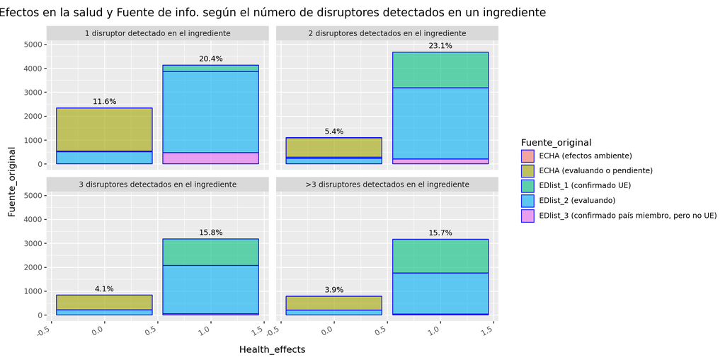

```python
# Graficamos Health_effects relleno con Fuente_original
facet_bar_pct(df, xcol="Health_effects", fill_col="Fuente_original", facet_col="num_disruptor_in_ingredient",
fig_width=12, fig_height=6, label_size=9,nudge_y=250,
title= "Efectos en la salud y Fuente de info. según el número de disruptores detectados en un ingrediente")
```

El gráfico muestra la relación entre efectos en salud `Health_effects` y la fuente de información `Fuente_original`, diferenciados según el número de grupos en los que se detectó un disruptor `num_disruptor_in_ingredient`.

**Número de disruptores detectados en el ingrediente = 1**

- El 20% de los casos presentan efectos en la salud.
- Las proporciones en esta faceta (=1) de las variables **Edlist_2 (en evaluación)** y **ECHA ED_pendiente** son bastante grandes, esto indica que los disruptores detectados no están confirmados por tanto, no habría un riesgo confirmado de estos ingredientes.

**Número de disruptores detectados en el ingrediente = 2, 3, > 3**

- El 23%, el 15,8% y el 15,7% de los casos respectivamente para cada facerta, presentan efectos en la salud.
- En todos destacan principalmente las fuentes **EDlist_2 (en evaluación)** y **EDlist_1 (confirmados por la UE)** .

**Conclusión**:

Podemos decir que un 75 % de toda la muestra tiene efectos para la salud y en todos existe una proporción de disruptores confirmados, siendo la proporción más alta de los que no lo están.

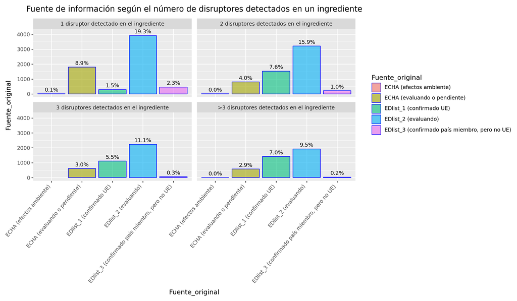

```python
# Graficamos Fuente_original
facet_bar_pct(df, xcol="Fuente_original", fill_col="Fuente_original", facet_col="num_disruptor_in_ingredient",
fig_width=12, fig_height=7, label_size=9, nudge_y=250,rotate=50,
title= "Fuente de información según el número de disruptores detectados en un ingrediente")
```

El gráfico muestra la relación entre la fuente de información `Fuente_original` y el número de grupos en los que se detectó un disruptor `num_disruptor_in_ingredient`.

**Número de disruptores detectados en el ingrediente = 1**

- Predomina el 19,3% y el 8,9% de los casos que están en evaluación.
- Esto indica que cuando el disruptor aparece en un solo grupo, la mayor parte de la información proviene de sustancias aún bajo evaluación.

**Número de disruptores detectados en el ingrediente = 2, 3 y >3**

**Conclusión**:

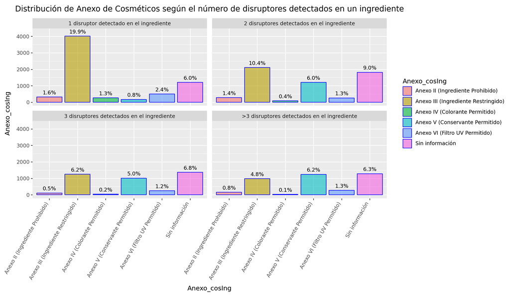

```python
# Graficamos Anexo_cosIng
facet_bar_pct(df, xcol="Anexo_cosIng", fill_col="Anexo_cosIng", facet_col="num_disruptor_in_ingredient",
fig_width=12, fig_height=7, label_size=9, nudge_y=250,rotate=60,
title= "Distribución de Anexo de Cosméticos según el número de disruptores detectados en un ingrediente")
```

El gráfico muestra la relación entre el `Anexo_cosIng` y el número de grupos en los que se detectó un disruptor `num_disruptor_in_ingredient`.

**Número de disruptores detectados en el ingrediente = 1**

- Predomina el **19,9% en Anexo III (ingredientes restringidos)**.
- Esto indica que cuando el disruptor aparece en un solo grupo, la mayor parte corresponde a sustancias que pueden estar presentes en cosméticos, pero con condiciones de uso.

**Conclusión**

La mayoría de los casos con un solo disruptor identificado se concentran en **Anexo III (restringidos)**.